# Coursera - USP - Processamento Neural de Linguagem Natural em Português I

[figure not shown]

## Lista 2 - NN & Backpropagation

Modificado por Leonardo Simões

## Sumário

- 1.Introdução
- 2.Perceptron
- 3.Questão 1
- 4.Questão 2
- 5.Prevendo se vai chover na Austrália
- 6.Questão 3
- 7.Questão 4
- Referências

## 1. Introdução

Atividades da semana 2 do curso "Processamento Neural de Linguagem Natural em Português I" oferecido pela USP através do Coursera.

```python
# Verificação da versão do Python
from platform import python_version
print('Versão do Python: ', python_version())
```

```
Versão do Python:  3.11.2
```

```python
# Imports das bibliotecas
import numpy as np
import pandas as pd
import matplotlib as mpl
import matplotlib.pyplot as plt
import seaborn as sns
from tensorflow import keras
import tensorflow as tf
from sklearn.model_selection import train_test_split
from sklearn.metrics import classification_report

%matplotlib inline
```

```python
# Versões das biblioteca
print('Numpy versão ' + np.__version__)
print('Pandas versão ' + pd.__version__)
print('Matplotlib versão ' + mpl.__version__)
print('Seaborn versão ' + sns.__version__)
print('TensorFlow versão ' + tf.__version__)
print('Keras versão ' + keras.__version__)
```

```
Numpy versão 1.23.5
Pandas versão 1.5.3
Matplotlib versão 3.7.0
Seaborn versão 0.12.2
TensorFlow versão 2.12.0
Keras versão 2.12.0
```

## 2. Perceptron

O perceptron é uma "rede neural" de um só neurônio. No nosso caso, temos a rede mais simples possível, com uma só entrada e uma só saída, sem ativação.

Temos 100 dados que serão usados para treinar 300 épocas do percéptron.

Vamos utilizar o modelo percéptron para aprender uma simples regressão linear, o objetivo é faze-lo aprender uma simples equação linear e tambem se acostumar com a sintaxe e funcionamento do TensorFlow

```python
# Funcao linear a ser aprendida
def f1(x):
    return 5 + 10*x
```

```python
# Calcula os valores de f1 em 100 valores no intervalo [0.10]
xs = np.linspace(0,10,100)
ys = f1(xs)
print('X:')
print(len(xs), "xs=", xs)
print('\nY:')
print(len(ys), "ys=", ys)
```

```
X:
100 xs= [ 0.          0.1010101   0.2020202   0.3030303   0.4040404   0.50505051
  0.60606061  0.70707071  0.80808081  0.90909091  1.01010101  1.11111111
  1.21212121  1.31313131  1.41414141  1.51515152  1.61616162  1.71717172
  1.81818182  1.91919192  2.02020202  2.12121212  2.22222222  2.32323232
  2.42424242  2.52525253  2.62626263  2.72727273  2.82828283  2.92929293
  3.03030303  3.13131313  3.23232323  3.33333333  3.43434343  3.53535354
  3.63636364  3.73737374  3.83838384  3.93939394  4.04040404  4.14141414
  4.24242424  4.34343434  4.44444444  4.54545455  4.64646465  4.74747475
  4.84848485  4.94949495  5.05050505  5.15151515  5.25252525  5.35353535
  5.45454545  5.55555556  5.65656566  5.75757576  5.85858586  5.95959596
  6.06060606  6.16161616  6.26262626  6.36363636  6.46464646  6.56565657
  6.66666667  6.76767677  6.86868687  6.96969697  7.07070707  7.17171717
  7.27272727  7.37373737  7.47474747  7.57575758  7.67676768  7.77777778
  7.87878788  7.97979798  8.08080808  8.18181818  8.28282828  8.38383838
  8.48484848  8.58585859  8.68686869  8.78787879  8.88888889  8.98989899
  9.09090909  9.19191919  9.29292929  9.39393939  9.49494949  9.5959596
  9.6969697   9.7979798   9.8989899  10.        ]

Y:
100 ys= [  5.           6.01010101   7.02020202   8.03030303   9.04040404
  10.05050505  11.06060606  12.07070707  13.08080808  14.09090909
  15.1010101   16.11111111  17.12121212  18.13131313  19.14141414
  20.15151515  21.16161616  22.17171717  23.18181818  24.19191919
  25.2020202   26.21212121  27.22222222  28.23232323  29.24242424
  30.25252525  31.26262626  32.27272727  33.28282828  34.29292929
  35.3030303   36.31313131  37.32323232  38.33333333  39.34343434
  40.35353535  41.36363636  42.37373737  43.38383838  44.39393939
  45.4040404   46.41414141  47.42424242  48.43434343  49.44444444
  50.45454545  51.46464646  52.47474747  53.48484848  54.49494949
  55.50505051  56.51515152  57.52525253  58.53535354  59.54545455
  60.55555556  61.56565657  62.57575758  63.58585859  64.5959596
  65.60606061  66.61616162  67.62626263  68.63636364  69.64646465
  70.65656566  71.66666667  72.67676768  73.68686869  74.6969697
  75.70707071  76.71717172  77.72727273  78.73737374  79.74747475
  80.75757576  81.76767677  82.77777778  83.78787879  84.7979798
  85.80808081  86.81818182  87.82828283  88.83838384  89.84848485
  90.85858586  91.86868687  92.87878788  93.88888889  94.8989899
  95.90909091  96.91919192  97.92929293  98.93939394  99.94949495
 100.95959596 101.96969697 102.97979798 103.98989899 105.        ]
```

```python
#Definindo, compilando e treinando nosso modelo
model = tf.keras.Sequential([
    keras.Input(shape=(1,)),
    keras.layers.Dense(units=1),
])

model.compile(optimizer="sgd", loss="mean_squared_error")
model.fit(xs,ys,epochs=300)
model.summary()
```

```
Model: "sequential"
_________________________________________________________________
 Layer (type)                Output Shape              Param #
=================================================================
 dense (Dense)               (None, 1)                 2

=================================================================
Total params: 2
Trainable params: 2
Non-trainable params: 0
_________________________________________________________________
```

```python
print("prediction: "+ str(model.predict([17]))+"      real value: " + str(f1(17)))
```

```
prediction: [[175.0168]]      real value: 175
```

```python
val = np.linspace(0,10,63)
model.evaluate(x=val, y=f1(val))
```

```
2.301573294971604e-05
```

## 3. Questão 1

Defina as camadas para rede neural a seguir e treine seu modelo, note que a saída unitária não deve ter função de ativação (por que?).

### Aprendendo uma função não linear

```python
# Funcao não linear a ser aprendida
def f2(x):
    return (x**2 + x*3 + 4)/200
```

```python
# Calcula os valores de f2 em 100 valores no intervalo [0.10] para treinamento
x = np.linspace(0,10,100)
y = f2(x)
```

```python
# Calcula os valores de f2 em 63 valores no intervalo [0.10] para validacao
x_val = np.linspace(0,10,63)
y_val = f2(x_val)
```

```python
def criar_modelo_redes_neural(x, y, ativacao='relu', otimizador='adam', perda='mean_squared_error', epocas=400):
    modelo = tf.keras.Sequential([
        keras.Input(shape=(1,)),
        keras.layers.Dense(10, activation=ativacao),
        keras.layers.Dense(1)
    ])

    modelo.compile(optimizer=otimizador, loss=perda)
    modelo.fit(x,y,epochs=epocas)

    return modelo
```

```python
def testar_valor_modelo(modelo, valor=17, funcao=f2):
    # Exbibe os valores predito e real
    valor_real, valor_predito = funcao(valor), modelo.predict([valor])[0,0]
    diferenca = abs(valor_real - valor_predito)
    print("Valor predito: "+ str(valor_real))
    print("Valor real: " + str(valor_predito))
    print("Diferença: " + str(diferenca))
```

```python
def avaliar_modelo(modelo, x_val, y_val):
    # Avalie o modelo no conjunto de teste
    loss = modelo.evaluate(x_val, y_val)
    print(f'Perda no conjunto de teste: {loss * 100:.2f}%')
```

```python
modelo_1 = criar_modelo_redes_neural(x, y, ativacao='relu', otimizador='adam', perda='mean_squared_error', epocas=400)
modelo_1.summary()
```

```
Model: "sequential_1"
_________________________________________________________________
 Layer (type)                Output Shape              Param #
=================================================================
 dense_1 (Dense)             (None, 10)                20

 dense_2 (Dense)             (None, 1)                 11

=================================================================
Total params: 31
Trainable params: 31
Non-trainable params: 0
_________________________________________________________________
```

```python
testar_valor_modelo(modelo_1)
```

```
Valor predito: 1.72
Valor real: 0.87769264
Diferença: 0.8423073601722717
```

```python
avaliar_modelo(modelo_1, x_val, y_val)
```

```
Perda no conjunto de teste: 0.44%
```

## 4. Questão 2

O que acontece se você muda as funções de ativação?

Teste algumas diferentes e descreva seus resultados, em especial a tangente hiperbólica.

```python
modelo_2 = criar_modelo_redes_neural(x, y, ativacao='tanh')
modelo_2.summary()
```

```
Model: "sequential_2"
_________________________________________________________________
 Layer (type)                Output Shape              Param #
=================================================================
 dense_3 (Dense)             (None, 10)                20

 dense_4 (Dense)             (None, 1)                 11

=================================================================
Total params: 31
Trainable params: 31
Non-trainable params: 0
_________________________________________________________________
```

```python
testar_valor_modelo(modelo_2)
```

```
Valor predito: 1.72
Valor real: 1.0058146
Diferença: 0.7141854476928711
```

```python
avaliar_modelo(modelo_2, x_val, y_val)
```

```
Perda no conjunto de teste: 0.02%
```

O que acontece se você mudar a função de otimização?

Teste diferentes funções e descreva seus resultados, em especial as funções SDG e RMSprop.

```python
modelo_3 = criar_modelo_redes_neural(x, y, otimizador='sgd')
modelo_3.summary()
```

```
Model: "sequential_3"
_________________________________________________________________
 Layer (type)                Output Shape              Param #
=================================================================
 dense_5 (Dense)             (None, 10)                20

 dense_6 (Dense)             (None, 1)                 11

=================================================================
Total params: 31
Trainable params: 31
Non-trainable params: 0
_________________________________________________________________
```

```python
testar_valor_modelo(modelo_3)
```

```
Valor predito: 1.72
Valor real: 1.0936476
Diferença: 0.6263524007797241
```

```python
type(modelo_3)
```

```
keras.engine.sequential.Sequential
```

```python
avaliar_modelo(modelo_3, x_val, y_val)
```

```
Perda no conjunto de teste: 0.17%
```

```python
modelo_4 = criar_modelo_redes_neural(x, y, otimizador='rmsprop')
modelo_4.summary()
```

```
Model: "sequential_4"
_________________________________________________________________
 Layer (type)                Output Shape              Param #
=================================================================
 dense_7 (Dense)             (None, 10)                20

 dense_8 (Dense)             (None, 1)                 11

=================================================================
Total params: 31
Trainable params: 31
Non-trainable params: 0
_________________________________________________________________
```

```python
testar_valor_modelo(modelo_4)
```

```
WARNING:tensorflow:5 out of the last 5 calls to <function Model.make_predict_function.<locals>.predict_function at 0x000002228B06B7E0> triggered tf.function retracing. Tracing is expensive and the excessive number of tracings could be due to (1) creating @tf.function repeatedly in a loop, (2) passin…
Valor predito: 1.72
Valor real: 1.1595368
Diferença: 0.5604631614685058
```

```python
avaliar_modelo(modelo_4, x_val, y_val)
```

```
WARNING:tensorflow:5 out of the last 9 calls to <function Model.make_test_function.<locals>.test_function at 0x0000022289B105E0> triggered tf.function retracing. Tracing is expensive and the excessive number of tracings could be due to (1) creating @tf.function repeatedly in a loop, (2) passing tens…
Perda no conjunto de teste: 0.06%
```

A principal diferença é que a tangente hiperbólica é centrada em 0 e produz valores no intervalo de -1 a 1, enquanto a ReLU é uma função de ativação não linear que produz valores maiores ou iguais a zero.

A mudança na função de ativação pode afetar a capacidade do modelo de se ajustar aos dados e a forma como ele aprende representações intermediárias. A escolha da função de ativação depende do problema específico e geralmente é feita através de experimentação para encontrar a função que melhor se adapta aos seus dados.

Volte a primeira parte desse notebook e troque a função de ativação da rede de uma camada (pérceptron) de sdg para adam, o que acontece?

```python
#Definindo, compilando e treinando nosso modelo
modelo_5 = tf.keras.Sequential([
    keras.layers.Dense(1, input_shape=(1,))
])

modelo_5.compile(optimizer="sgd", loss="mean_squared_error")
modelo_5.fit(xs,ys,epochs=300)
modelo_5.summary()
```

```
Model: "sequential_5"
_________________________________________________________________
 Layer (type)                Output Shape              Param #
=================================================================
 dense_9 (Dense)             (None, 1)                 2

=================================================================
Total params: 2
Trainable params: 2
Non-trainable params: 0
_________________________________________________________________
```

```python
# Exbibe os valores predito e real para x=17
print("Valor predito: "+ str(modelo_5.predict([17]))+"\nValor real: " + str(f1(17)))
```

```
WARNING:tensorflow:6 out of the last 6 calls to <function Model.make_predict_function.<locals>.predict_function at 0x000002228EAFD300> triggered tf.function retracing. Tracing is expensive and the excessive number of tracings could be due to (1) creating @tf.function repeatedly in a loop, (2) passin…
Valor predito: [[175.00916]]
Valor real: 175
```

```python
# Avalia o modelo pela função loss que é o erro quadrático médio (MSE)
val = np.linspace(0,10,63)
modelo_5.evaluate(x=val, y=f1(val))
```

[output not shown]

```
1.7035405107890256e-05
```

A avaliação de performance que realizamos foi apenas para pontos contidos no mesmo intervalo que o conjunto de treino, ou seja, foi apenas uma interpolação. Sem alterar sua rede repita o teste realizando uma extrapolação, com pontos fora do intervalo [0;10] e descreva seus resultados.

O que aconteceu com a performance ?

| Modelo | Perda |
| --- | --- |
| 1 | 0,0044 |
| 2 | 0,00015 |
| 3 | 0,0017 |
| 4 | 0,00064 |
| 5 | 0,000017 |

## 5. Prevendo se vai chover na Austrália

Os próximos exercícios são, em grande parte, uma tradução e adaptação para o português brasileiro do tutorial intitulado [Build Your First Neural Network with Pytorch](https://curiousily.com/posts/build-your-first-neural-network-with-pytorch/) entretanto algumas adaptações foram realizadas, tanto no texto, quanto no código, em relação à versão original para utilizar a biblioteca TensorFlow.

Aqui você aprenderá como implementar, treinar e utilizar uma Rede Neural *Feed-Foward* simples para uma tarefa de classificação binária.

Para tal, utilizaremos o pacote TensorFlow 2.0 que é, atualmente, uma das principais ferramentas para a implementação de modelos neurais viáveis.

A tarefa que usaremos para fins de exemplo será a de prever se choverá ou não numa cidade australiana amanhã, utilizando dados meteorológicos mensurados na mesma cidade no dia de hoje. A redução dessa tarefa de previsão a uma classificação binária é, evidentemente, uma grande simplificação do problema real de previsão meteorológica, mas como veremos, ainda pode apresentar resultados interessantes, além do caráter didático.

As informações que utilizaremos para treinar nosso modelo para a tarefa de previsão de chuvas estão contidas num conjunto que reúne dados meteorológicos de diversas cidades australianas. Esse conjunto de dados foi curado e disponibilizado através do [Kaggle](https://www.kaggle.com/jsphyg/weather-dataset-rattle-package) por [Joe Young](https://www.kaggle.com/jsphyg).

Já definimos uma função basica para lhe ajudar a explorar os dados, você precisará escrever uma função para carregar os dados, uma de pré-processamento e outra para fazer a separação em teste e treino.

Os dados estão no formato `.csv` e, com eles em mãos, o primeiro passo é carregá-los em um *data-frame*, usando a função [`pd.read_csv()`](https://pandas.pydata.org/pandas-docs/stable/reference/api/pandas.read_csv.html) do *pandas*.

Com os dados carregados, é possível averiguar que eles são constituídos por 142193 entradas, cada uma contando com 24 variáveis distintas. É possível notar, também, que existem entradas para as quais nem todas as variáveis estão instanciadas. Além disso, nem todos os valores estão nos formatos que gostaríamos que estivessem para serem processados.

Isso é normal. Dados reais são cheios de falhas e problemas, e exigem trabalho e entendimento para serem utilizados da maneira correta. Por isso, é necessário realizar um **pré-processamento** para adequar os dados, antes de os passarmos para o modelo.

O primeiro passo é escolher quais das variáveis meteorológicas nos interessam. No nosso caso, queremos prever se choverá ou não amanhã, então `RainTomorrow` será nossa variável alvo. Para prevê-la usaremos as variáveis `Rainfall`, `Humidity3pm`, `Pressure9am` e `RainToday`, que serão nossas *features*.

Em seguida, iniciamos o pré-processamento, propriamente dito.

As variáveis `RainToday` e `RainTomorrow` possuem dois valores possíveis, *Yes* e *No*. Adeque esses valores, convertendo-os para $1$ e $0$, respectivamente.

A seguir, remova todas as entradas que não tenham instanciado os valores de todas as variáveis de interesse com a função [`dropna()`](https://pandas.pydata.org/pandas-docs/stable/reference/api/pandas.DataFrame.dropna.html), pois essas entradas são inúteis para treinar nosso modelo.

Com os dados pré-processados, é possível, agora, plotar as distribuições das variáveis de interesse para poder entender melhor como essas distribuições funcionam. Esse tipo de trabalho é muito importante na implementação real de redes neurais, conhecer os dados é fundamental para tirar o maior proveito do seu modelo e entender verdadeiramente seus resultados.

Dentre todas as distribuições das variáveis de interesse, a que mais nos concerne é a da variável alvo, `RainTomorrow`, representada na figura acima.

Essa distribuição nos revela um grande desbalanço entre os dois valores possíveis dessa variável, que constituirão as duas classes do nosso problema de classificação. Esse é um dado importante, pois pode influenciar significativamente a capacidade preditiva do modelo treinado.

Existem maneiras de se lidar com o desbalanceamento dos dados, mas nesse tutorial utilizaremos os dados dessa forma. Isso significa que o *baseline* para a performance do nosso modelo deve ser $78\%$, isso porque, se um modelo chutasse que amanhã não irá chover, todas as vezes, ele obteria uma performance dessa ordem e, como esperamos gerar um modelo mais "inteligente" que isso, esperamos também que a a nossa performance seja superior a essa.

Todo o código referente a esse pré-processamento deve ser escrito pelo próprio aluno seguindo o esqueleto das funções presentes no notebook. Para agilizar a exploração dos dados nós já fornecemos a implementação da função `visualize_data()` que plota visualizações para as distribuições das variáveis de interesse.

```python
def visualize_data(data):
    """Gera graficos das distribuicoes das features"""

    ibm_pltt = ['#648FFF', '#785EF0', '#DC267F',
                '#FE6100', '#FFB000']  # Paleta colorblind-friendly

    # RainToday:
    sns.set()
    sns.set_palette(sns.color_palette([ibm_pltt[2], ibm_pltt[0]]))
    sns.countplot(x=data.RainToday)
    plt.xlabel('Choveu Hoje?')
    plt.ylabel('Contagem')
    plt.title("Valores de 'RainToday' para os dados pré-processados")
    plt.show()

    # RainTomorrow:
    sns.set()
    sns.set_palette(sns.color_palette([ibm_pltt[3], ibm_pltt[1]]))
    sns.countplot(x=data.RainTomorrow)
    plt.xlabel('Choverá Amanhã?')
    plt.ylabel('Contagem')
    plt.title("Valores de 'RainTomorrow' para os dados pré-processados")
    plt.show()

    # Humidity3pm:
    sns.set()
    sns.displot(data.Humidity3pm, color=ibm_pltt[0], stat='density', kde=True)
    plt.xlabel('Umidade às 3PM')
    plt.ylabel('Densidade normalizada')
    plt.title("Distribuição da variável 'Humidity3pm' para os dados pré-processados")
    plt.show()

    # Pressure9am:
    sns.set()
    sns.displot(data.Pressure9am, color=ibm_pltt[4], stat='density', kde=True)
    plt.xlabel('Pressão atmosférica às 9AM')
    plt.ylabel('Densidade normalizada')
    plt.title("Distribuição da variável 'Pressure9amm' para os dados pré-processados")
    plt.show()

    # Rainfall:
    sns.set()
    sns.histplot(data.Rainfall, color=ibm_pltt[1], bins=500, kde=False)
    plt.xlim(0, 10)
    plt.xlabel('Pluviosidade')
    plt.ylabel('Densidade normalizada')
    plt.title("Distribuição da variável 'Rainfall' para os dados pré-processados")
    plt.show()

    return
```

### Pré processamento dos dados

Já definimos uma função basica para lhe ajudar a explorar os dados, você precisará escrever uma função para carregar os dados, uma de pré-processamento e outra para fazer a separação em teste e treino.

## 6. Questão 3

Complete as funções aqui descritas seguindo a assinatura sugerida Para separar em treino e teste, de uma olhada na função train_test_split() do Scikit-Learn.

```python
def load_data(data_path='data/weatherAUS.csv')-> pd.DataFrame:
    """Funcao que importa dados de um arquivo csv, usando pandas"""
    #Seu código aqui
    raw_data = pd.read_csv('data/weatherAUS.csv')

    return raw_data


def pre_processing(raw_data:pd.DataFrame)-> pd.DataFrame:
    """Funcao que filtra e limpa os dados meteorologicos para o treinamento"""
    #Seu código aqui
    colunas = ['RainTomorrow', 'Rainfall', 'Humidity3pm', 'Pressure9am', 'RainToday']
    processed_data = raw_data[colunas]

    assert set(processed_data.columns.values) == set(colunas)

    processed_data = processed_data.dropna()

    assert processed_data.isna().sum().sum() == 0

    assert set(processed_data['RainToday'].value_counts().index) == {'No', 'Yes'}
    assert set(processed_data['RainTomorrow'].value_counts().index) == {'No', 'Yes'}

    processed_data.loc[processed_data['RainToday'] == 'No', 'RainToday'] = '0'
    processed_data.loc[processed_data['RainToday'] == 'Yes', 'RainToday'] = '1'
    processed_data.loc[processed_data['RainTomorrow'] == 'No', 'RainTomorrow'] = '0'
    processed_data.loc[processed_data['RainTomorrow'] == 'Yes', 'RainTomorrow'] = '1'

    assert set(processed_data['RainToday'].value_counts().index) == {'0','1'}
    assert set(processed_data['RainTomorrow'].value_counts().index) == {'0','1'}

    processed_data['RainToday'] = processed_data['RainToday'].astype(int)
    processed_data['RainTomorrow'] = processed_data['RainTomorrow'].astype(int)

    assert set(processed_data.dtypes.values) == {np.dtype(int), np.dtype(float)}
    assert set(processed_data['RainToday'].value_counts().index) == {0,1}
    assert set(processed_data['RainTomorrow'].value_counts().index) == {0,1}

    return processed_data


def split_data(data:pd.DataFrame, val_size= 0.2)-> np.array:
    """Funcao que separa seus dados em teste e treino conforme a proporcao val_size"""
    #Seu código aqui
    X = data[['Rainfall', 'Humidity3pm', 'Pressure9am', 'RainToday']]
    y = data['RainTomorrow']
    x_train, x_val, y_train, y_val = train_test_split(X, y, test_size=val_size, random_state=42)

    return x_train, x_val, y_train, y_val
```

```python
# Carga e pré-processamentos dos dados
df = load_data()
df = pre_processing(df)
df.head()
```

|  | RainTomorrow | Rainfall | Humidity3pm | Pressure9am | RainToday |
| --- | --- | --- | --- | --- | --- |
| 0 | 0 | 0.6 | 22.0 | 1007.7 | 0 |
| 1 | 0 | 0.0 | 25.0 | 1010.6 | 0 |
| 2 | 0 | 0.0 | 30.0 | 1007.6 | 0 |
| 3 | 0 | 0.0 | 16.0 | 1017.6 | 0 |
| 4 | 0 | 1.0 | 33.0 | 1010.8 | 0 |

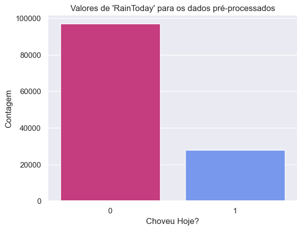

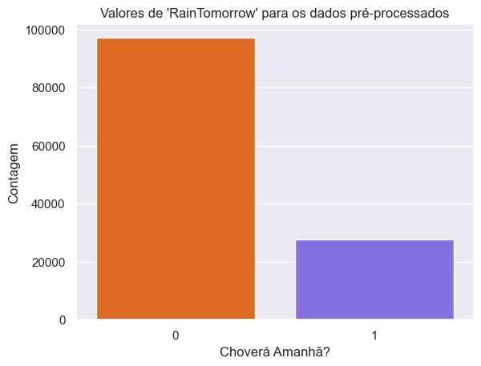

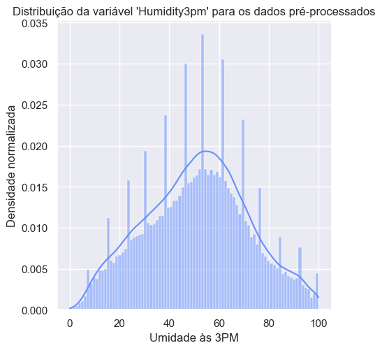

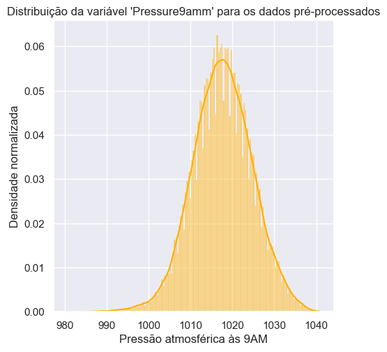

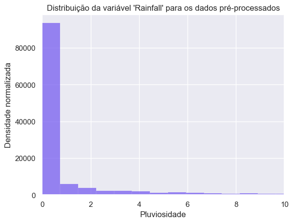

```python
# Visualização dos dados pré-processados
visualize_data(df)
```

```python
# Divisão dos dados em treino e teste
x_train, x_val, y_train, y_val = split_data(df,)
```

## 7. Questão 4

Agora que você já ganhou uma familiaridade com a API Keras, escreva sozinho do começo ao fim um modelo que ira dizer se amanhã vai chover ou não e avalie sua performance.

```python
# Crie o modelo Keras
modelo_6 = keras.Sequential([
    keras.layers.Dense(16, activation='relu', input_shape=(x_train.shape[1],)),
    keras.layers.Dense(1, activation='sigmoid')
])

# Compile o modelo
modelo_6.compile(optimizer='adam', loss='binary_crossentropy', metrics=['accuracy'])

# Treine o modelo
modelo_6.fit(x_train, y_train, epochs=10, batch_size=64, validation_split=0.2)
```

```
<keras.callbacks.History at 0x22291bc1d10>
```

```python
# Avalie o modelo no conjunto de teste
loss = modelo_6.evaluate(x_val, y_val)
print(f'Perda no conjunto de teste: {round(loss * 100,2)}')
```

[output not shown]

```python
loss
```

```
[0.40557748079299927, 0.8345096111297607]
```

```python
# Faça previsões
y_pred = modelo_6.predict(x_val)

# Converta as probabilidades em rótulos binários (0 ou 1)
y_pred = (y_pred > 0.5).astype(int)

# Relatório de classificação
print(classification_report(y_val, y_pred))
```

[output not shown]

## Referências

Coursera - USP - Processamento Neural de Linguagem Natural em Português I: https://www.coursera.org/learn/processamento-neural-linguagem-natural-em-portugues-i

Lista 2 - NN & Backpropagation: https://colab.research.google.com/github/alan-barzilay/NLPortugues/blob/master/Semana%2002/02%20-%20NN%20_%20Backpropagation.ipynb